# Workshop 2 - Chi-Square Tests for Categorical Variables

## Goals

In this workshop, you will learn how to:

- Perform Chi square tests to compare a data set and a hypothetical situation
- Create a contingency table of counts of categorical data
- Performing Chi square tests on a contingency table to assess the independence of categorical variables

# Categorical Data (revisited)

Categorical data is data where each observation belongs to one of $k$ categories. It is essential to remember that **categories are not numbers** and we can not treat them as if they are. So most of our standard methods of analysis are inapplicable or inappropriate.

Typically, we would summarise categorical data by the counts that each category is observed in the data. These summary counts can be grouped into a **contingency** table which tabulates the counts of observations that fall into each category. When we have more than one categorical variable, we can also tabulate the counts observed for every combination of categories.

Having reduced our data to numerical values (though they are still *discrete* counts), we can begin to ask some questions of interest:

1. Do the observed counts agree with some hypothetical situation?
2. If not, what are the deviations from the hypothetical situation?
3. If any, why might there be such deviations?

## Goodness of fit

Suppose a dice is rolled 60 times. We do not know if the die is fair or biased. How do we test the hypothesis that the dice is fair? We can summaries the outcomes of the dice rolls by the counts of the different outcomes:

[output not shown]

A **goodness of fit** test assesses how well a hypothesised statistical model describes fits a set of observations. Our hypotheses for the test are simply:

- $H_0$: the hypothetical model is correct
- $H_1$: the hypothetical model is incorrect.

What *exactly* the hypothetical model is depends entirely on the problem. In the case of the dice example, our hypothetical model is simply that “the dice is fair”.

To set up our test, let’s introduce some notation. Let $O_i$ be the **observed frequency** for the $i$th category from the data. Now let’s call $E_i$ the **expected frequency** for the $i$th category when our hypothetical model is true. For the dice example, we observe 12 sixes - $O_6=12$, and if the dice was fair (under $H_0$), we would expect to see $E_6=60/6=10$ sixes.

We can set this up in the following table. If we wite $p_i$ as the probability of each category under $H_0$, then $p_i=1/6$ for each outcome of the dice roll. Our expected counts are then $E_i= n \times p_i$, and this completes this table.

[output not shown]

If the model $H_0$ were true, we would expect an agreement between the values of $O_i$ and $E_i$. If not then we might expect to see some substantial differences between $O_i$ and $E_i$. Comparing the $O_i$ values with the $E_i$ shows some small differences, but perhaps nothing overwhelming.

Let’s look at the differences $O_i-E_i$ in the table below. This is adding some information on the *direction* of any disagreement, (we see fewer 1s than expected) but if we were to sum all the differences up to get an overall score then we always get zero (why?). We could try *squaring* the differences and look at $(O_i-E_i)^2$, then this will stop the sum being zero. It will also emphasise the effect of large differences, and shrink the effect of small differences. However, when $E_i$ like our example here then a difference of 5 may be “big”, but if $E_i=1000$ then a difference of 5 is “small” and probably ignorable! To account for this, let’s also divide each squared difference by $E_i$. The quantities $(O_i-E_i)^2/E_i$ are now a measure of the *relative* disagreement between $O_i$ and $E_i$. Summing these values will give us an overall indication how different the $O$ are from the $E$ overall.

For our dice example, we see the score for `1` is largest, indicating this is in most disagreement with the null hypothesis. The overall score is 5, but is this big enough to reject our hypothesis?

| Score | 1 | 2 | 3 | 4 | 5 | 6 | Total |
| --- | --- | --- | --- | --- | --- | --- | --- |
| $O_i$ | 5 | 11 | 8 | 10 | 14 | 12 | 60 |
| $E_i$ | 10 | 10 | 10 | 10 | 10 | 10 | 60 |
| $O_i-E_i$ | -5 | 1 | -2 | 0 | 4 | 2 | 0 |
| $(O_i-E_i)^2$ | 25 | 1 | 4 | 0 | 16 | 4 | 38 |
| $X^2=(O_i-E_i)^2/E_i$ | 2.5 | 0.1 | 0.4 | 0 | 1.6 | 0.4 | 5 |

## Pearson Residuals and the $\chi^2$ test

For category $i$, we define the **Pearson residual** as
$$r_i=\frac{O_i-E_i}{\sqrt{E_i}}$$
.

Under $H_0$, we have that approximately that our goodness-of-fit test statistic is
$$X^2=\sum_{i=1}^k r_i^2= \sum_{i=1}^k\frac{(O_i-E_i)^2}{E_i} \sim
\chi^2_{k-1}$$
where $\chi^2_{k-1}$ is the chi-squared distribution with $k-1$ degrees of freedom and $k$ is the total number of categories for our variable.

We would then reject $H_0$ at level $\alpha$ if our calculated value of $X^2\geq \chi^\ast$, where $\chi^\ast$ is such that $P[X^2\geq \chi^\ast]=\alpha$.

Our table for the dice example above gives us a test statistic of 5. Comparing this to the $\chi^2$ distribution with parameter $6-1=5$ gives a $p$-value of $0.4159$. This p-value is quite large and so our observations here are not surprising enough that they would cause us to doubt the fairness of the dice. More formally, we find no evidence to reject the hypothesis that this dice is fair at the 5% level (or the 10% level, or the 20% level, …)

Rather than doing this by hand, R can perform a $\chi^2$ test if provided the observed counts and the expected probabilities under $H_0$:

```r
chisq.test(c(5,11,8,10,14,12), p=c(1/6,1/6,1/6,1/6,1/6,1/6))
```

```
##
##  Chi-squared test for given probabilities
##
## data:  c(5, 11, 8, 10, 14, 12)
## X-squared = 5, df = 5, p-value = 0.4159
```

The resulting output reports the test statistic (`X-squared`), its parameter or ‘degrees of freedom’ (`df`), the the corresponding p-value.

## Challenge

1. Load the built-in mtcars dataset in your R environment.
2. Produce a vector with the counts of categories (4, 6, and 8 cylinders) in the categorical variable ‘cyl’
3. Produce a vector with the expected counts of those categories (4, 6, and 8 cyl) assuming a uniform distribution
4. Run a Chi-square test to check if you shall reject the null hypothesis. What are your conclusions?

**Click for solution**

```r
data(mtcars)

# Extract cylinder counts
cyl_counts <- table(mtcars$cyl)

# Run the chi-squared goodness-of-fit test
result <- chisq.test(cyl_counts, p = c(1/3, 1/3, 1/3))

# Output the result
print(result)
```

```
##
##  Chi-squared test for given probabilities
##
## data:  cyl_counts
## X-squared = 2.3125, df = 2, p-value = 0.3147
```

The $p$-value is too big to confidently reject the null hypothesis. In other words, we can **not** infer that the distribution of cylinders in cars in the mid ’70s has a pattern different than the uniform one.

Comments:

- **Note:** while we haven’t delved into the details, the chi-squared test is only reliable when:
  - all categories have $E_i\geq 1$
  - at least 80% of categories have $E_i\geq 5$
- If these criteria are not satisfied, then we should combine (‘pool’) categories together until they are met.
- Expected frequenciesare determined by the probability of the population falling into category $i$ under the model $H_0$. The expected frequency $E_i$ is then this proportion multiplied by the total sample size. The model specified by $H_0$ can be as simple as the example above, or the result of any complex model fitting.

## Contingency Tables

To motivate analysing categorical data, we will revisit with the `titanic` data set available as part of the basic R installation:

```r
titanic <- data.frame(Titanic)
```

The Titanic data set provides information on the fate of passengers on the fatal maiden voyage of the Titanic, summarized according to economic status (class), sex, age and survival. The variables are all categorical:

- **Class** - 1st, 2nd, 3rd, or crew
- **Sex** - male, or female
- **Age** - child, or adult
- **Survived** - survived or died

The data themselves are already summarised into counts (`Freq`) for each combination of each variable:

```r
titanic[1:10,]
```

```
##    Class    Sex   Age Survived Freq
## 1    1st   Male Child       No    0
## 2    2nd   Male Child       No    0
## 3    3rd   Male Child       No   35
## 4   Crew   Male Child       No    0
## 5    1st Female Child       No    0
## 6    2nd Female Child       No    0
## 7    3rd Female Child       No   17
## 8   Crew Female Child       No    0
## 9    1st   Male Adult       No  118
## 10   2nd   Male Adult       No  154
```

Thus the first row corresponds to the counts of 1st class male children who did not survive - in this case zero. Note that many categories have counts of zero. This is known as *sparsity* and occurs often when dealing with many categorical variables at once. Due to the large number of possible combinations of the possible factors of the different variables, it is quite unlikely to observe all possible combinations in a single data set unless it is particularly large.

Our analysis in Lecture 1 showed considerable differences when considering a single variable at a time:

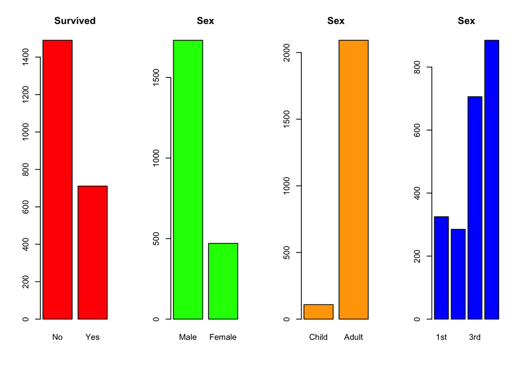

```r
par(mfrow=c(1,4))
barplot(xtabs(Freq~Survived,data=titanic), col="red",main="Survived")
barplot(xtabs(Freq~Sex,data=titanic), col="green",main="Sex")
barplot(xtabs(Freq~Age,data=titanic), col="orange",main="Sex")
barplot(xtabs(Freq~Class,data=titanic), col="blue",main="Sex")
```

However, the way to answer our question will require thinking about more than one variable at a time, and how they may (or may not) interact.

Let’s focus on the class of the passengers (`Class`) and their survival (`Survived`). The class variable has 4 possible values (1st, 2nd, 3rd, Crew), and survival has 2 possibilities (`Yes`,`No`) - thus we have 8 possible combinations. We can summarise the counts of passengers in each combination in a $4\times2$ table. As we are tabulating two variables, this is called a **2-way contingency table**:

```r
library(knitr)
kable(xtabs(Freq~Survived+Class,data=titanic))
```

|  | 1st | 2nd | 3rd | Crew |
| --- | --- | --- | --- | --- |
| No | 122 | 167 | 528 | 673 |
| Yes | 203 | 118 | 178 | 212 |

It can also be useful to append the totals for each row and column to the summary:

```r
library(knitr)
tab <- xtabs(Freq~Survived+Class,data=titanic)
tab <- rbind(tab, apply(tab,2,sum))
tab <- cbind(tab, apply(tab,1,sum))
colnames(tab)[5] <- 'Total'
rownames(tab)[3] <- 'Total'
kable(tab)
```

|  | 1st | 2nd | 3rd | Crew | Total |
| --- | --- | --- | --- | --- | --- |
| No | 122 | 167 | 528 | 673 | 1490 |
| Yes | 203 | 118 | 178 | 212 | 711 |
| Total | 325 | 285 | 706 | 885 | 2201 |

Here we have summarised the fates of all the passengers, divided up by class or crew status. For example, we can easily see that far more 1st class passengers survived than did not, whereas the opposite was true for those in 3rd class. This would suggest that there is some association here to explore.

We can then summarise this in the 2-way table below, where the levels of variable 1 are the rows of the table, and the levels of variable 2 are the columns:

| Var 1\ Var 2 | 1 | 2 | … | $j$ | … | $C$ | Total |
| --- | --- | --- | --- | --- | --- | --- | --- |
| **1** | $o_{11}$ | $o_{12}$ | … | $o_{1j}$ | … | $o_{1C}$ | $r_1$ |
| **2** | $o_{21}$ | $o_{22}$ | … | $o_{2j}$ | … | $o_{2C}$ | $r_2$ |
| $\vdots$ | $\vdots$ | $\vdots$ | $\ddots$ | $\vdots$ | $\ddots$ | $\vdots$ | $\vdots$ |
| **i** | $o_{i1}$ | $o_{i2}$ | … | $o_{ij}$ | … | $o_{iC}$ | $r_i$ |
| $\vdots$ | $\vdots$ | $\vdots$ | $\ddots$ | $\vdots$ | $\ddots$ | $\vdots$ | $\vdots$ |
| **R** | $o_{R1}$ | $o_{R2}$ | … | $o_{Rj}$ | … | $o_{RC}$ | $r_R$ |
| **Total** | $c_1$ | $c_2$ | … | $c_j$ | … | $c_C$ | $n$ |

Here we have also introduce notation for the row and columns sums:

- $r_i$ is the sum of counts in the $i$th row. This corresponds to the number of observations of level $i$ of Variable 1. The collection of row counts $r_1,\dots,r_R$ corresponds to the counts for all the different levels of Variable 1.
- $c_j$ is the sum of counts in the $j$th row. This corresponds to the number of observations of level $j$ of Variable 2. The collection of row counts $c_1,\dots,c_C$ corresponds to the counts for all the different levels of Variable 2.

### Creating Contingency Tables

We can use the `xtabs` function from Lecture 1 to construct these contingency tables from data. There are two different usages, depending on whether the data has been pre-summarised as counts (like the Titanic data), or if the data is not summarised and each row corresponds to a single observation.

If the data is summarised already, and contains the totals in column called `counts`, then the summary of counts for the levels of `variable1` is obtained by:

```r
xtabs(counts~variable1, data=dataset)
```

For example, to summarise survival:

```r
xtabs(Freq~Survived,data=titanic)
```

```
## Survived
##   No  Yes
## 1490  711
```

For 2-way tables, we simply add another variable to the right of the `~` symbol:

```r
xtabs(counts~variable1+variable2, data=dataset)
```

For example, to summarise combinations of survival with class of passenger:

```r
xtabs(Freq~Survived+Class,data=titanic)
```

```
##         Class
## Survived 1st 2nd 3rd Crew
##      No  122 167 528  673
##      Yes 203 118 178  212
```

### n-way Contingency Tables

When we have $n$ categorical variables, we could create an $n$-way contingency table. The table would summarise the counts of every possible combination of every possible level of the $n$ variables. This obviously gets more complicated with larger $n$, but we’ll come back to this later.

For instance, we could summarise the combinations of Titanic passenger survival, passenger class *and* passenger sex:

```r
xtabs(Freq~Survived+Class+Sex, data=titanic)
```

```
## , , Sex = Male
##
##         Class
## Survived 1st 2nd 3rd Crew
##      No  118 154 422  670
##      Yes  62  25  88  192
##
## , , Sex = Female
##
##         Class
## Survived 1st 2nd 3rd Crew
##      No    4  13 106    3
##      Yes 141  93  90   20
```

## A Test for Contingency Tables

Exploring the independence of a pair of variables can lead to valuable insights in exploration and modelling. Specifically, we are interested in associations (or lack of associations) between variables, as these often point to potential interesting relationships in the data.

Typically, in statistics, we frame this problem from the opposite perspective and ask whether there is an absence of association or dependency between variables. This absence of association corresponds to the concept of **independence** of the corresponding variables, which is associated with statistical and probabilistic properties that can be investigated.

For example, we could ask whether `Survived` is independent from `Class` in the Titanic data. If we find evidence to the contrary, then we may conclude there is an association or relationship between the two. The key idea behind using independence as the property to verify is that if two variables $X$ and $Y$ are independent, then we can write
$$P[X=x,Y=y]=P[X=x]P[Y=y],$$
or equivalently in terms of conditional probabilitiy:
$$P[X=x | Y=y]=P[X=x].$$
The second version tells us that *even if I were to tell you the value of Y*, that would not cause you to change your probability distribution for $X$. In other words, knowing $Y$ has no influence on how we thinkg $X$ will behave - in other words, the two variables are completely unrelated.

We’ll develop a simple test for assessing this, based on these simple equations. As a running example, let’s continue with the Titanic data and investigate possible relationships between `Survived` and `Class`. The idea behind our test is as follows:

1. Using the data, we can estimate the probabilities of the different levels of `Survived` ($p_i$) and `Class` ($p_j$) separately using the proportions of the data observed in each category.
2. Under a hypothesis of independence, I can use the first equation above to tell me that the probability of any combination of `Survived` and `Class` is just the product of individual probabilities from the previous step, $p_{ij}=p_i p_j$. Applying this to all combinations of categories gives me the probability for every possible combination of the two variables, $p_{ij}$.
3. The expected number of observations in each combination of categories is obtained by multiplying the probabilities from step 2 by the sample size $n$. This gives the *expected counts* for every combination, $E_{ij}=np_{ij}$.
4. We can then compare our expected counts to the *observed* counts in the data, and construct a test statistic.

Let’s see how this goes with our data:

**Observed counts:** We observe the following counts of the different categories of `Survived` and `Class`

| No | Yes |
| --- | --- |
| 1490 | 711 |

| 1st | 2nd | 3rd | Crew |
| --- | --- | --- | --- |
| 325 | 285 | 706 | 885 |

**Observed proportions:** Dividing the observed counts by the sample size ($n=2201$) gives the proportions of the data observed in each category:

| No | Yes |
| --- | --- |
| 0.676965 | 0.323035 |

| 1st | 2nd | 3rd | Crew |
| --- | --- | --- | --- |
| 0.1476602 | 0.1294866 | 0.3207633 | 0.40209 |

Unsuprisingly, the more common categories are now associated with larger proportions.

**Probabilities of combinations under independence** We assume the null hypothesis to be $H_0$: survival is independent from class. Then we can say, for example:

$$P[Survived=Yes,Class=1st] =
P[Survived=Yes]\times P[Class=1st],$$

and the same for all the other combinations. By multiplying our probabilities from the previous step, we can make the following probability table for the joint distribution of `Survived` and `Class` under our null hypothesis of independence:

|  | 1st | 2nd | 3rd | Crew |
| --- | --- | --- | --- | --- |
| No | 0.0999608 | 0.0876579 | 0.2171455 | 0.2722008 |
| Yes | 0.0476994 | 0.0418287 | 0.1036178 | 0.1298891 |

**Expected counts under independence** Multiplying these probabilities by the number of passengers will give us the expected number of passengers ($E$) in each group under independence:

|  | 1st | 2nd | 3rd | Crew |
| --- | --- | --- | --- | --- |
| No | 220.0136 | 192.93503 | 477.9373 | 599.114 |
| Yes | 104.9864 | 92.06497 | 228.0627 | 285.886 |

We can now compare these *expected* counts with the ones we actually *observed*. If we find big differences, then we would conclude our hypothesis of independence must be wrong and that there is evidence of some form of relationship.

## Performing $\chi^2$ tests

|  | 1st | 2nd | 3rd | Crew |
| --- | --- | --- | --- | --- |
| No | $\color{blue}{\text{-6.608}}$ | $\color{blue}{\text{-1.867}}$ | $\color{red}{\text{2.290}}$ | $\color{red}{\text{3.019}}$ |
| Yes | $\color{red}{\text{9.566}}$ | $\color{red}{\text{2.703}}$ | $\color{blue}{\text{-3.315}}$ | $\color{blue}{\text{-4.370}}$ |

Here we notice the very large values in the 1st class column - we see far $\color{red}{\text{more}}$ survivors than expected and far $\color{red}{\text{fewer}}$ fatalities. The pattern appears to be reversed for those in 3rd class and the ship’s crew. Clearly, first class passengers had far better outcomes than would be expected if the chances were equal for everyone on board.

Finally, there’s no real need to do this entire calculation by hand as R easily perform an independence test for a contingency table. All we need to supply is the table of observed values obtained from `xtabs`:

```r
chisq.test( xtabs(Freq~Survived+Class,data=titanic) )
```

```
##
##  Pearson's Chi-squared test
##
## data:  xtabs(Freq ~ Survived + Class, data = titanic)
## X-squared = 190.4, df = 3, p-value < 2.2e-16
```

**Click for solution**

Solution:

```r
data(HairEyeColor)

# Create the contingency table
contingency_table <- xtabs(Freq~Hair+Eye, data=HairEyeColor)

# Run the chi-squared test
chisq.test(contingency_table)
```

```
##
##  Pearson's Chi-squared test
##
## data:  contingency_table
## X-squared = 138.29, df = 9, p-value < 2.2e-16
```